# Chap11_section1

퀸즐랜드와 노던 테리토리와 같은 북부 주는 열대 기후와 우기인 여름 때문에 겨울(3분기)에 방문객이 가장 많다. 반면, 남부에 위치한 빅토리아와 태즈메이니아는 여름(1분기)에 방문이 집중된다. 이러한 계절 패턴은 Figure 11.4의 계절성 그래프에서 뚜렷하게 나타난다.

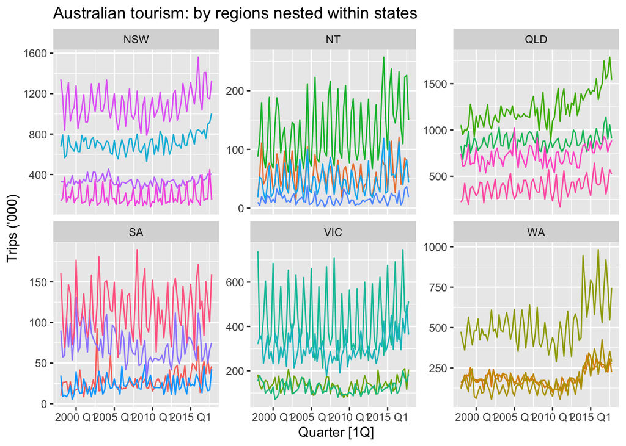

```r
plot_regions <- c(
  "North Coast NSW", "Snowy Mountains", "Hunter", "New England North West",
  "Alice Springs", "Darwin", "Kakadu Arnhem", "MacDonnell",
  "Brisbane", "Gold Coast", "Northern Outback", "Sunshine Coast",
  "Tropical North Queensland",
  "Adelaide Hills", "Murraylands", "Yorke Peninsula", "Kangaroo Island",
  "Ballarat", "Great Ocean Road", "High Country", "Goulburn",
  "Australia's Coral Coast", "Australia's Golden Outback",
  "Australia's North West", "Australia's South West"
)

tourism_plot <- tourism |>
  as_tibble() |>
  group_by(Quarter, State, Region) |>
  summarise(Trips = sum(Trips), .groups = "drop") |>
  filter(
    State %in% c("NSW", "NT", "QLD", "SA", "VIC", "WA"),
    Region %in% plot_regions
  ) |>
  mutate(
    State = factor(State, levels = c("NSW", "NT", "QLD", "SA", "VIC", "WA"))
  )

ggplot(tourism_plot, aes(x = Quarter, y = Trips, colour = Region, group = Region)) +
  geom_line(show.legend = FALSE) +
  facet_wrap(~ State, scales = "free_y", ncol = 3) +
  labs(
    title = "Australian tourism: by regions nested within states",
    x = "Quarter [1Q]",
    y = "Trips ('000)"
  )
```

Figure 11.5: Domestic overnight trips from 1998 Q1 to 2017 Q4 for some selected regions.

Figure 11.5의 그래프는 일부 선택된 지역의 데이터를 보여주며, 각 주 내 지역별로 다양한 시계열 특성을 시각화할 수 있게 한다. 일부 지역은 뚜렷한 추세나 계절성을 보이는 반면, 일부는 반대되는 계절성 또는 단순한 노이즈처럼 보이는 양상을 나타낸다.

### 그룹화된 시계열 (Grouped Time Series)

가장 상위 수준에는 전체 집계값인 **Total** 시계열 $y_t$가 위치하며, 이는 다양한 속성(attribute)에 따라 분해될 수 있다. 예를 들어:

- 속성 A, B에 따라: $y_{A,t},\ y_{B,t}$
- 속성 X, Y에 따라: $y_{X,t},\ y_{Y,t}$

하위 수준에서는 A/B와 X/Y 속성이 결합된 형태로 데이터가 분해된다. 즉, 그룹화된 시계열에서는 하나의 고정된 트리 구조가 아닌, **다차원적인 분류 구조**를 기반으로 데이터가 구성된다.

이러한 구조는 산업, 제품 유형, 지역 등 복수의 분류 기준이 동시에 존재할 때 유용하게 사용된다.

#### 그룹화된 시계열의 집계 경로

이 예제는 그룹화된 구조에서는 다양한 집계 경로가 가능하다는 점을 보여준다. 시점 $t$에서 전체 시계열은 다음과 같이 표현된다:

$$y_t = y_{AX,t} + y_{AY,t} + y_{BX,t} + y_{BY,t}$$

#### 첫 번째 수준의 집계 경로

속성 A/B에 따라 그룹화할 경우:

$$y_{A,t} = y_{AX,t} + y_{AY,t}, \quad
y_{B,t} = y_{BX,t} + y_{BY,t} \tag{11.3}$$

속성 X/Y에 따라 그룹화할 경우:

$$y_{X,t} = y_{AX,t} + y_{BX,t}, \quad
y_{Y,t} = y_{AY,t} + y_{BY,t} \tag{11.4}$$

이처럼 그룹화된 시계열은 **유일한 계층적 구조를 강제하지 않는다**는 특징이 있다. 즉, 어떤 순서로 속성을 기준으로 그룹화하느냐에 따라 서로 다른 집계 구조를 만들 수 있다.

#### 계층형 시계열과의 비교

그룹화된 시계열은 종종 계층적 시계열의 일반화된 형태로 간주될 수 있다. 다만, **고정된 분해 순서가 존재하지 않으며**, 다양한 기준에 따라 데이터를 집계하거나 분해할 수 있다는 점에서 차이가 있다.

### 예시: 호주 교도소 수감자 수

- 1. **주(state)** 기준
- 2. **법적 지위(legal status)**: 이미 형을 선고받은 경우 vs. 선고를 기다리는 구금 상태(remand)
- 3. **성별(gender)**

이 세 가지 분류 기준은 서로 교차된(crossed) 관계를 가지며, 어느 것도 다른 분류 안에 포함된(nested) 구조는 아니다.

#### 그룹 구조의 특성

- 각 요인은 독립적인 범주형 변수이며, 다양한 방식으로 조합(grouping)될 수 있다.
- 이는 **그룹화된 시계열(grouped time series)**의 대표적인 예로, 고정된 계층적 분해 방식이 아닌 교차적 기준에 따른 분해가 가능하다.

이러한 구조는 다양한 사회경제적 요인에 따른 수감자 수 변화 패턴을 분석하는 데 유용하다.

```r
prison <- readr::read_csv("https://OTexts.com/fpp3/extrafiles/prison_population.csv") |>
  mutate(Quarter = yearquarter(Date)) |>
  select(-Date)  |>
  as_tsibble(key = c(Gender, Legal, State, Indigenous),
             index = Quarter) |>
  relocate(Quarter)
```

```
## `curl` package not installed, falling back to using `url()`
##
```

aggregate_key() 함수를 사용할 때, 관심 있는 속성들을 교차시키려면 attribute1 * attribute2 형태의 문법을 사용한다. 이는 계층적 시계열에서 사용하는 parent/child 구문과는 다르다. 예를 들어, 성별(gender), 법적 지위(legal status), **주(state)**를 교차하여 그룹화된 시계열(tsibble)을 생성할 수 있다.

```r
prison_gts <- prison |>
  aggregate_key(Gender * Legal * State, Count = sum(Count)/1e3)
```

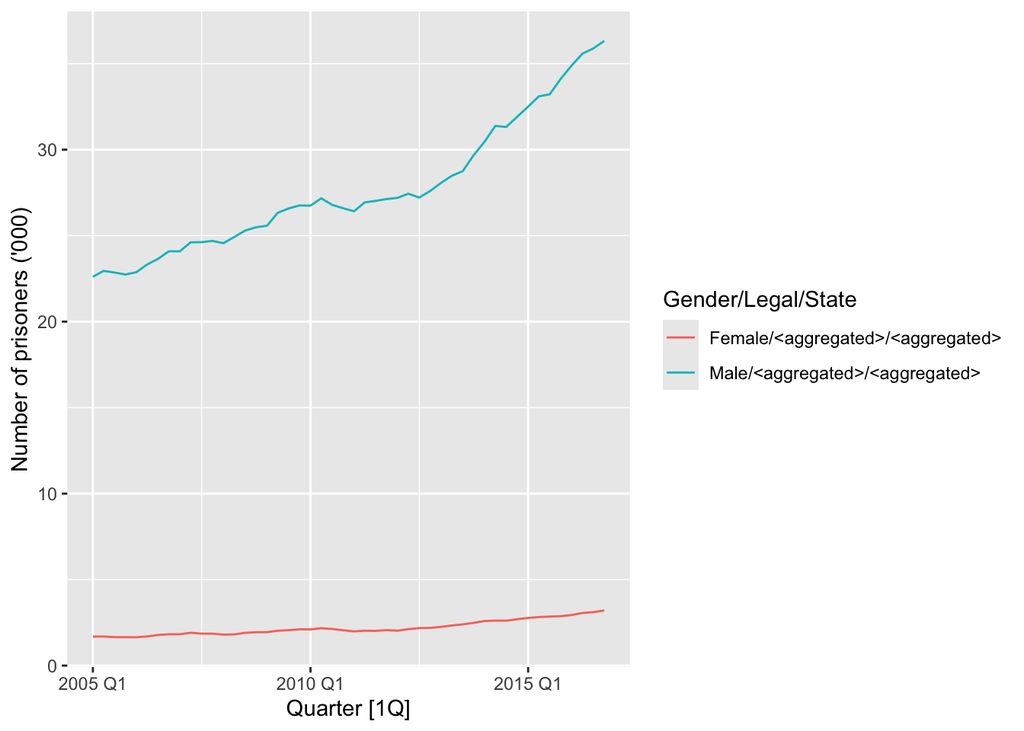

```r
prison_gts |>
  filter(!is_aggregated(Gender), is_aggregated(Legal),
         is_aggregated(State)) |>
  autoplot(Count) +
  labs(y = "Number of prisoners ('000)")
```

Figure 11.8에서는 호주 수감자 데이터를 두 개 속성씩 조합하여 그룹화한 시계열을 보여준다. 예: 주와 성별, 주와 법적 지위, 성별과 법적 지위의 조합이다. 이와 같은 다양한 그룹 조합에 대한 그래프는 유사한 방식으로 생성할 수 있으며, Figure 11.8의 첫 번째 그래프는 해당 조합 중 하나를 나타낸다.

Figure 11.8: Australian adult prison population disaggregated by pairs of attributes.

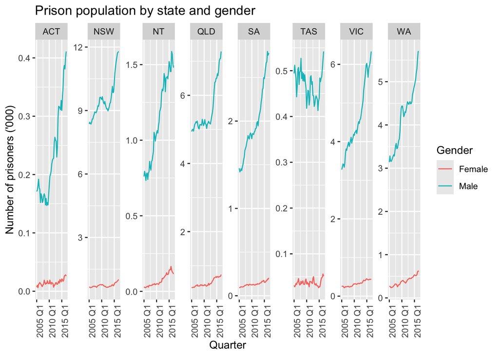

```r
prison_gts |>
  filter(!is_aggregated(Gender), !is_aggregated(Legal),
         !is_aggregated(State)) |>
  mutate(Gender = as.character(Gender)) |>
  ggplot(aes(x = Quarter, y = Count,
             group = Gender, colour=Gender)) +
  stat_summary(fun = sum, geom = "line") +
  labs(title = "Prison population by state and gender",
       y = "Number of prisoners ('000)") +
  facet_wrap(~ as.character(State),
             nrow = 1, scales = "free_y") +
  theme(axis.text.x = element_text(angle = 90, hjust = 1))
```

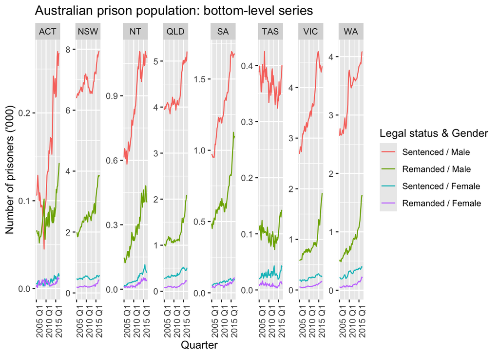

```r
prison_gts |>
  filter(!is_aggregated(Gender),
         !is_aggregated(Legal),
         !is_aggregated(State)) |>
  mutate(
    Gender = as.character(Gender),
    Legal = as.character(Legal),
    series = factor(
      paste(Legal, Gender, sep = " / "),
      levels = c(
        "Sentenced / Male",
        "Remanded / Male",
        "Sentenced / Female",
        "Remanded / Female"
      )
    )
  ) |>
  ggplot(aes(x = Quarter, y = Count,
             group = series, colour = series)) +
  geom_line() +
  labs(
    title = "Australian prison population: bottom-level series",
    y = "Number of prisoners ('000)",
    colour = "Legal status & Gender"
  ) +
  facet_wrap(~ as.character(State),
             nrow = 1, scales = "free_y") +
  theme(axis.text.x = element_text(angle = 90, hjust = 1))
```

Figure 11.9는 호주 성인 수감자 데이터를 주(state), 법적 지위(legal status), **성별(gender)**의 세 가지 속성으로 분해한 결과를 보여준다. 이들은 그룹 구조에서 **최하위 수준 시계열(bottom-level series)**을 구성한다.

Figure 11.9: Bottom-level time series for the Australian adult prison population, grouped by state, legal status and gender.

### 혼합된 계층 및 그룹 구조

혼합된 계층 및 그룹 구조에서는 분해 기준이 **중첩(nested)**되기도 하고 **교차(crossed)**되기도 한다. 예를 들어, 호주 관광 데이터는 여행 목적(휴가, 출장, 친지 방문, 기타)으로도 분해될 수 있는데, 이 변수는 지리적 변수와는 중첩되지 않는다. 따라서 전체 호주, 각 주, 각 지역별로 여행 목적에 따른 숙박 여행을 나눌 수 있으며, 이는 지리적 계층 구조에 여행 목적이 교차된 구조로 볼 수 있다. 이 구조는 aggregate_key() 함수에서 단순히 요인을 결합하여 지정할 수 있다.

```r
tourism_full <- tourism |>
  aggregate_key((State/Region) * Purpose, Trips = sum(Trips))
```

tourism_full tsibble은 총 425개 시계열을 포함한다. 이 중 85개는 지리적 계층 구조에서 유래하며, 나머지 340개는 각 계층 시계열이 여행 목적과 교차되어 생성된 시계열이다.

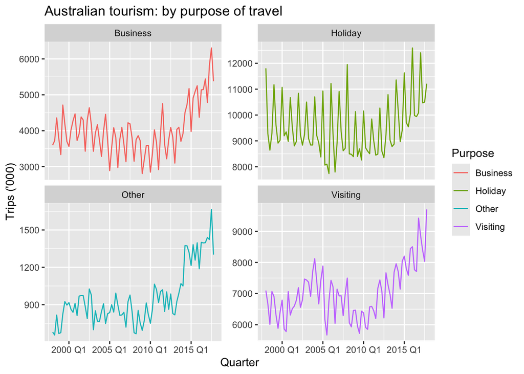

```r
tourism_full |>
  filter(
    is_aggregated(State),
    is_aggregated(Region),
    !is_aggregated(Purpose)
  ) |>
  mutate(
    Purpose = factor(
      as.character(Purpose),
      levels = c("Business", "Holiday", "Other", "Visiting")
    )
  ) |>
  ggplot(aes(x = Quarter, y = Trips,
             colour = Purpose, group = Purpose)) +
  geom_line() +
  facet_wrap(~ Purpose, ncol = 2, scales = "free_y") +
  labs(
    title = "Australian tourism: by purpose of travel",
    x = "Quarter",
    y = "Trips ('000)"
  )
```

Figure 11.10: Australian domestic overnight trips from 1998 Q1 to 2017 Q4 disaggregated by purpose of travel.

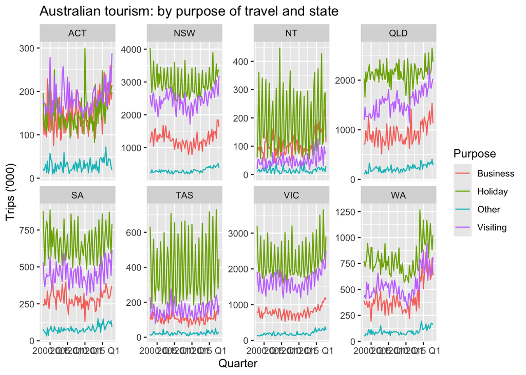

```r
tourism_full |>
  filter(
    !is_aggregated(State),
    is_aggregated(Region),
    !is_aggregated(Purpose)
  ) |>
  mutate(
    Purpose = factor(
      as.character(Purpose),
      levels = c("Business", "Holiday", "Other", "Visiting")
    ),
    State = factor(
      as.character(State),
      levels = c("ACT", "NSW", "NT", "QLD", "SA", "TAS", "VIC", "WA")
    )
  ) |>
  ggplot(aes(x = Quarter, y = Trips,
             colour = Purpose, group = Purpose)) +
  geom_line() +
  facet_wrap(~ State, ncol = 4, scales = "free_y") +
  labs(
    title = "Australian tourism: by purpose of travel and state",
    x = "Quarter",
    y = "Trips ('000)",
    colour = "Purpose"
  )
```

Figure 11.11: Australian domestic overnight trips over the period 1998 Q1 to 2017 Q4 disaggregated by purpose of travel and by state.

Figure 11.10과 11.11은 시계열을 여행 목적별, 그리고 **여행 목적과 주(state)**별로 그룹화한 집계 시계열을 보여주며, 이들 시계열에서 다양하고 풍부한 동적 특성이 나타남을 확인할 수 있다.